# lab7_basic plot

zewahyu

## Basic Multipanel Layouts with `par()`

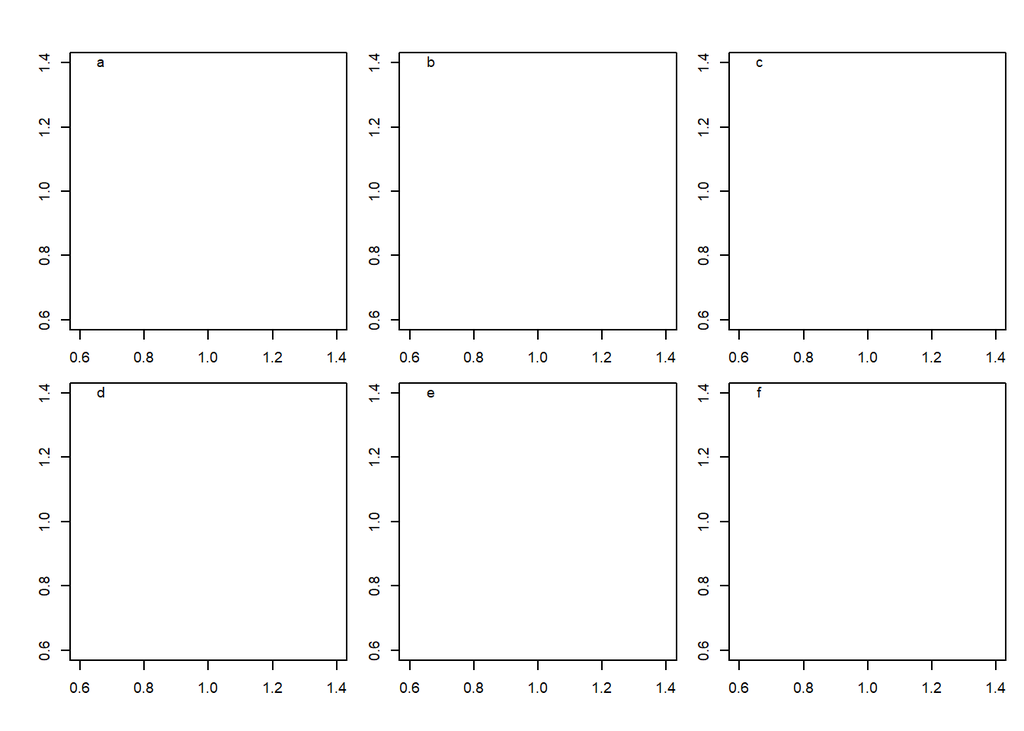

```r
par(mfrow = c(2, 3), cex = 0.6, mar = c(3, 3, 0, 0), oma = c(1, 1, 3, 1))
for (i in 1:6) {
  plot(1, 1, type = "n")
  mtext(letters[i], side = 3, line = -1, adj = 0.1,cex = 0.6)
}
```

## Some of the Common “Tricks”

We can eliminate the redundant axes, remove margin space, and reduce the emphasis on the structural (non-data) elements of the figure.

```r
par(mfrow = c(2, 3), cex = 0.6, mar = c(0, 0, 0, 0), oma = c(4, 4, 0.5, 0.5),tcl = -0.25, mgp = c(2, 0.6, 0))
for (i in 1:6) {
  plot(1, axes = FALSE, type = "n")
  mtext(letters[i], side = 3, line = -1, adj = 0.1, cex = 0.6)
  if (i %in% c(4, 5, 6)) axis(1, col = "grey40", col.axis = "grey20", at = seq(0.6, 1.2, 0.2))
  if (i %in% c(1, 4)) axis(2, col = "grey40", col.axis = "grey20", at = seq(0.6, 1.2, 0.2))
  box(col = "grey60")
}

mtext("x axis", side = 1, outer = TRUE, cex = 0.7, line = 2.2, col = "grey20")
mtext("y axis", side = 2, outer = TRUE, cex = 0.7, line = 2.2, col = "grey20")
```

We can eliminate the redundant axes, remove margin space, and reduce the emphasis on the structural (non-data) elements of the figure.

[figure not shown]

## Fancy Multipanel Layouts with `layout()`

`layout()` takes a matrix and turns it into a layout. The numbers in the matrix correspond to the order that the panels will be plotted in. Cells with the same number represent a single panel.

```r
(m <- rbind(c(1, 1), c(2, 3)))
```

```
##      [,1] [,2]
## [1,]    1    1
## [2,]    2    3
```

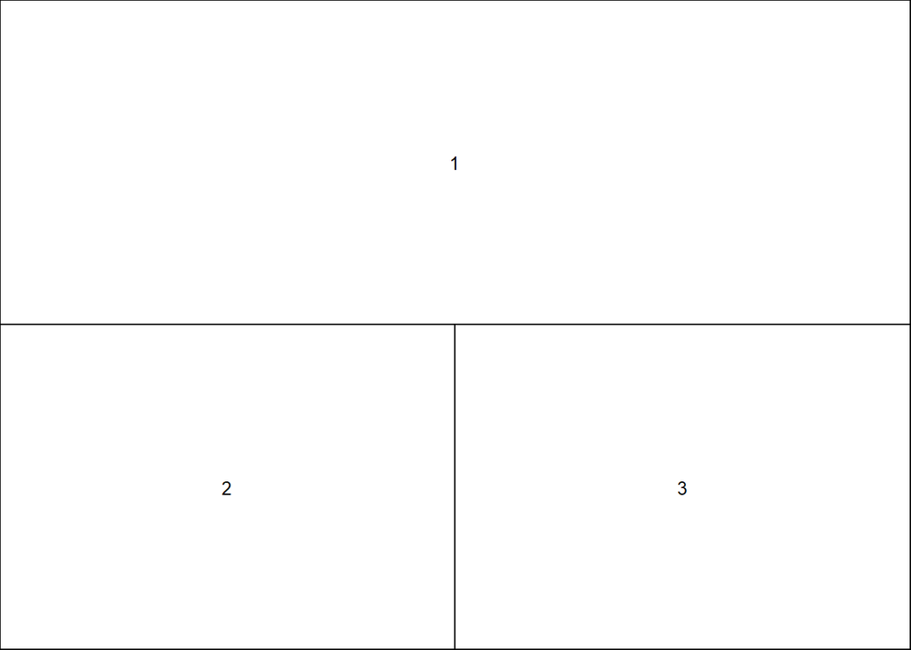

````r
layout(m)
layout.show(3) # The number of the panels to show```
````

We can create some fairly complex layouts with `layout()`. For example, some panels empty can be left empty as margin space.

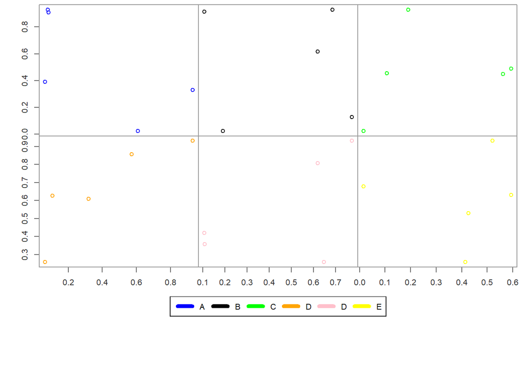

```r
m <- matrix(c(1,2,3,4,5,6,7,7,7),nrow = 3,ncol = 3,byrow = TRUE)
layout(mat = m,heights = c(0.4,0.4,0.2))
par(oma = c(4, 4, 0.5, 0.5))
plot_colors <- c("blue","black", "green", "orange", "pink", "yellow")
for (i in 1:6){
    par(mar = c(0, 0, 0, 0))
    plot(runif(5),runif(5), axes=FALSE,col=plot_colors[i])
    if (i %in% c(4, 5, 6)) axis(1, col = "grey40", col.axis = "grey20")
    if (i %in% c(1, 4)) axis(2, col = "grey40", col.axis = "grey20")
    box(col = "grey60")
}
par(mar = c(0, 0, 3, 0))
plot(1, type = "n", axes=FALSE, xlab="", ylab="")
legend(x = "top",inset = 0,
        legend = c("A", "B", "C","D", "D", "E"),
        col=plot_colors, lwd=5, horiz = TRUE)
```

```r
?legend
```

```
## starting httpd help server ... done
```

We can set parameter values based on other data using `ifelse` function

```r
tib = tibble(day = 1:10, value=11:20)
tib
```

```
## # A tibble: 10 x 2
##      day value
##    <int> <int>
##  1     1    11
##  2     2    12
##  3     3    13
##  4     4    14
##  5     5    15
##  6     6    16
##  7     7    17
##  8     8    18
##  9     9    19
## 10    10    20
```

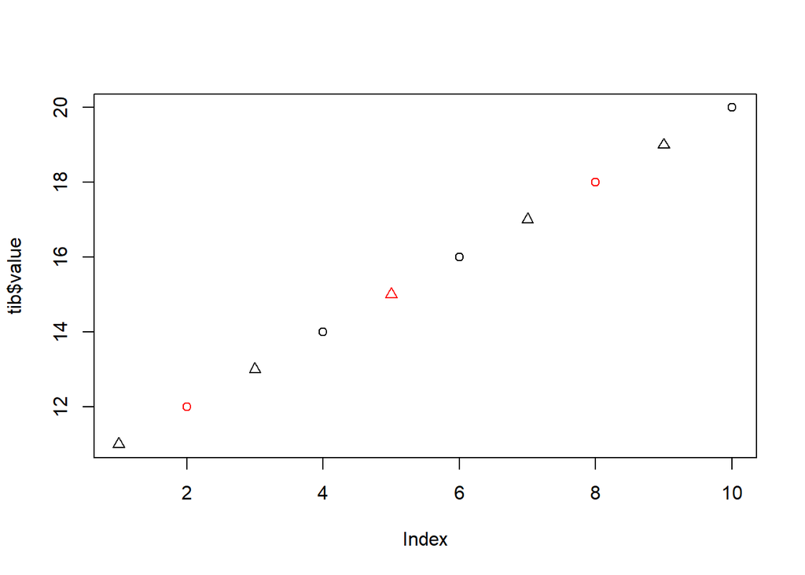

```r
plot(tib$value, col=ifelse(tib$value%%3 == 0, "red","black"), pch=ifelse(tib$value%%2 == 0, 1, 2))
```

In the above example, we can first evaluate the value assigned to `col` and `pch`.

```r
(c=ifelse(tib$value%%3 == 0, "red","black"))
```

```
##  [1] "black" "red"   "black" "black" "red"   "black" "black" "red"   "black"
## [10] "black"
```

```r
(p=ifelse(tib$value%%2 == 0, 1, 2))
```

```
##  [1] 2 1 2 1 2 1 2 1 2 1
```

`plot(x=tib$value, col=ifelse(tib$value%%3 == 0, "red","black"), pch=ifelse(tib$value%%2 == 0, 1, 2))`

## Task:

You are going to plot a graph to show the stock price, 50-day moving average, 200-day moving average, death cross and golden cross of Facebook and Apple inc. in year 2018.

The datasets is the trimmed data containing the columns `date`, `Adjusted`(Adjusted Price), `x50day.SMA` (50-day simple moving average), `x200day.SMA` (200-day simple moving average) and `cross` (Death/Golden Cross happens on that day)

For the value of `Nday.SMA`, it is the average close price of the previous N day. For example, the 50day.SMA of day 51 is `mean(close_price[1:50])`, where the `close_price` column was removed. The 200day.SMA of day 1000 is `mean(close_price[800:999])`

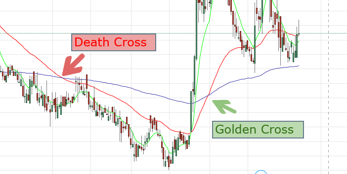

Death / Golden Cross

(The red line is 50-day moving average. The blue line is 200-day moving average.)

The death cross is the intersection point of 50-day SMA and 200-day SMA that the 50-day SMA was previously higher than the 200-day SMA but now becomes lower.

The golden cross is the intersection point of 50-day SMA and 200-day SMA that the 50-day SMA was previously lower than the 200-day SMA but now becomes higher.

```r
(FB = read_csv("FB.csv"))
```

```
## # A tibble: 251 x 5
##    date       Adjusted x50day.SMA x200day.SMA cross
##    <date>        <dbl>      <dbl>       <dbl> <chr>
##  1 2018-01-02     181.       178.        163. <NA>
##  2 2018-01-03     185.       178.        163. <NA>
##  3 2018-01-04     184.       178.        163. <NA>
##  4 2018-01-05     187.       178.        163. <NA>
##  5 2018-01-08     188.       179.        164. <NA>
##  6 2018-01-09     188.       179.        164. <NA>
##  7 2018-01-10     188.       179.        164. <NA>
##  8 2018-01-11     188.       180.        164. <NA>
##  9 2018-01-12     179.       180.        165. <NA>
## 10 2018-01-16     178.       180.        165. <NA>
## # ... with 241 more rows
```

```r
(AAPL = read_csv("AAPL.csv"))
```

```
## # A tibble: 251 x 5
##    date       Adjusted x50day.SMA x200day.SMA cross
##    <date>        <dbl>      <dbl>       <dbl> <chr>
##  1 2018-01-02     167.       170.        156. <NA>
##  2 2018-01-03     167.       170.        156. <NA>
##  3 2018-01-04     168.       171.        156. <NA>
##  4 2018-01-05     170.       171.        156. <NA>
##  5 2018-01-08     169.       171.        157. <NA>
##  6 2018-01-09     169.       172.        157. <NA>
##  7 2018-01-10     169.       172.        157. <NA>
##  8 2018-01-11     170.       172.        157. <NA>
##  9 2018-01-12     172.       172.        157. <NA>
## 10 2018-01-16     171.       173.        157. <NA>
## # ... with 241 more rows
```

```r
tail(AAPL)
```

```
## # A tibble: 6 x 5
##   date       Adjusted x50day.SMA x200day.SMA cross
##   <date>        <dbl>      <dbl>       <dbl> <chr>
## 1 2018-12-21     148.       194.        194. <NA>
## 2 2018-12-24     145.       193.        194. <NA>
## 3 2018-12-26     155.       191.        194. <NA>
## 4 2018-12-27     154.       190.        194. <NA>
## 5 2018-12-28     154.       189.        194. <NA>
## 6 2018-12-31     155.       187.        193. <NA>
```

Here are the sub-tasks you need to complete:

- Plot 2 subgraphs; Upper one is for FB; Lower one is for AAPL;
- For each company(FB and AAPL):
  1. Plot a line graph (value: `Adjusted` column, style: dash line, darkgrey color)
  2. Add a title “COMPANY_NAME stock pring 2018”. (You can use `line=-1` to adjust title position)
  3. Add a line to show the 50day-moving average (style: orange color)
  4. Add a line to show the 200day-moving average (style: blue color)
  5. If death cross happens on that day, add a red inverted triangle, and label “Death Cross”; If golden cross happens on that day, add a green triangle, and label “Golden Cross”
- For the first graph (FB):
  - remove the x label and xtick
  - add a legend at the bottom right corner

```r
# Edit Here
# (You also need to edit the given par())
par(mfrow = c(2, 1), cex = 0.6, mar = c(0, 3, 0, 0), oma = c(4, 4, 0.5, 0.5),tcl = -0.25, mgp = c(2, 0.6, 0))
```

#### Expected Output:

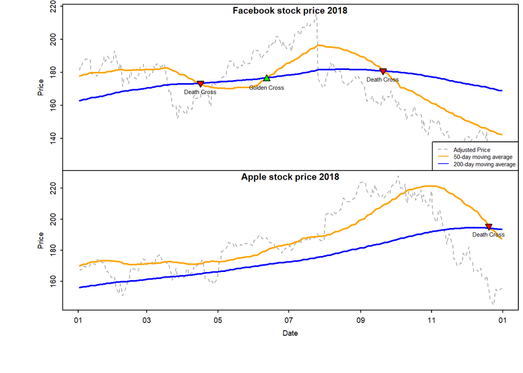